# Configurer et utiliser Gnomic

Tonon Laurie

15/03/2021

# Présentation du cluster

Gnomic est constitué d’une machine frontale, d’une baie de stockage NFS de 500 To et de 12 noeuds de calcul.  
Chaque noeud de calcul possède 64 processeurs et 512Gb de RAM.

La baie NFS est réservée à la plateforme de bioinformatique, des solutions de stockage Isilon pour le CRCL et le CLB vont être déployées par la DSI à part.

[figure not shown]

Vous pouvez organiser votre home comme vous le voulez et installer vos données dedans.  
Un système de warning et de quota sera mis en place pour limiter la taille des répertoire.

Un système de sauvegarde sur bande sera rapidement déployé. Pour faciliter la sauvegarde des données essentielles des utilisateurs il vous faudra créer un dossier **save** à la racine de votre home. Seuls les fichiers de ce dossier seront sauvegardés sur bande (vous pouvez faire des liens symboliques pour éviter de déplacer des fichiers si besoin).  
On rappelle que cette sauvegarde sert uniquement pour des fichiers qu’on ne peut pas reproduire facilement, ce qui dans notre cas correspond surtout à du code. Les données brutes seront sauvegardées par ailleurs, et les données processées peuvent être regénérées avec les codes sauvés.

# Connexion et configuration

## Accès ssh

Gnomic est accessible depuis le réseau CLB à l’adresse 192.168.206.11.  
Pour se connecter il faut utiliser les identifiants de son compte CLB (identifiants de messagerie unicancer par exemple).  
Depuis l’extérieur il est possible de rebondir sur master pour l’instant pour accéder à gnomic:

```bash
ssh tonon@192.168.206.11
```

Une fois connecté vous arrivez dans votre home directory sur la machine frontal:

[figure not shown]

Depuis la machine frontal vous avez accès à internet pour télécharger des logiciels, données etc… Par contre ce n’est pas une machine sur laquelle on travaille, une fois les choses installées et configurées il faut utiliser les noeuds de calculs. On reverra ça par la suite.

## Configurer son environnement

Vous pouvez customiser votre environnement personel avec les fichiers cachés ".bash*".

Par exemple pour modifier l’aspect de la barre d’invitation de commande et avoir de belles couleurs comme moi, il faut modifier ou créer le fichier “~/.bash_utils” et copier cela à l’intérieur:

```bash
#-------------------------------------------------------------
# Shell Prompt
#-------------------------------------------------------------

function bash-prompt-custom() {
# regular colors
local K="\[\033[0;30m\]"    # black
local R="\[\033[0;31m\]"    # red
local G="\[\033[0;32m\]"    # green
local Y="\[\033[0;33m\]"    # yellow
local B="\[\033[0;34m\]"    # blue
local M="\[\033[0;35m\]"    # magenta
local C="\[\033[0;36m\]"    # cyan
local W="\[\033[0;37m\]"    # white

# empahsized (bolded) colors
local EMK="\[\033[1;30m\]"
local EMR="\[\033[1;31m\]"
local EMG="\[\033[1;32m\]"
local EMY="\[\033[1;33m\]"
local EMB="\[\033[1;34m\]"
local EMM="\[\033[1;35m\]"
local EMC="\[\033[1;36m\]"
local EMW="\[\033[1;37m\]"

# background colors
local BGK="\[\033[40m\]"
local BGR="\[\033[41m\]"
local BGG="\[\033[42m\]"
local BGY="\[\033[43m\]"
local BGB="\[\033[44m\]"
local BGM="\[\033[45m\]"
local BGC="\[\033[46m\]"
local BGW="\[\033[47m\]"

local NC='\[\033[0m\]'


case $TERM in
    xterm*)
        TITLEBAR='\[\033]0;\u@\h : \w\007\]'
        ;;
    *)
        TITLEBAR=""
        ;;
esac

PS1="${TITLEBAR}\
$EMG\h\
$W[\
$EMM\$(date +%H:%M)\
$W] \
$EMR\
\W$W \$ $NC"

}
```

Et ensuite pareil, créer ou modifier le fichier “~/.bashrc” en ajoutant:

```bash
#-------------------------------------------------------------
# Source ~/.bash_utils (if any)
#-------------------------------------------------------------
if [ -f ~/.bash_utils ]; then
        . ~/.bash_utils
        bash-prompt-custom
fi
```

On peut ajouter divers alias ou changement de PATH dans le fichier “~/.bashrc”, de cette façon ils seront pris en compte à chaque fois que vous vous connecterez.  
Par exemple:

```bash
alias ll='ls -l'
```

Pour que les modfications soient prises en compte, il faut se déconnecter et revenir.

# Conda

## Qu’est-ce que c’est?

Conda est un outil qui permet de créer et gérer des environnements virtuels facilement. Chaque environnement permet d’installer des packages et leurs dépendances facilement et de manière encapsulée (i.e: 2 outils ayant les mêmes dépendances vont les installer chacun dans son environnement).  
Par exemple vous avez besoin d’utiliser Python version 3.8 mais la version de base de python de la machine est la 2.7. En quelques commandes vous pouvez créer un environnement conda avec la bonne version de Python, sans toucher à la configuration de la machine, et utiliser votre outil.

Conda a son propre gestionnaire de packages, cela permet d’installer, updater et enlever des outils à un environnement très facilement.

## Installer et configurer Conda

L’installation de conda est simple, il suffit de récupérer le script d’installation de miniconda.

```bash
wget https://repo.anaconda.com/miniconda/Miniconda3-latest-Linux-x86_64.sh
```

Cela va importer le fichier **Miniconda3-latest-Linux-x86_64.sh**.

On lance le script:

```bash
sh Miniconda3-latest-Linux-x86_64.sh
```

Et l’installation se fait toute seule. Il va poser quelques questions: choisissez où vous voulez qu’il installe miniconda dans votre home et acceptez le reste par défaut.  
Quand l’installation est terminée, déconnectez-vous de gnomic et revenez pour que les changements soient effectifs.  
Pour tester que tout va bien:

```bash
conda env list
```

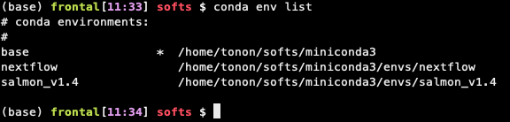

J’ai déjà des environnements créés chez moi mais vous ne devriez voir que l’environnement base.

Le gestionnaire de package de conda utilise des channels pour chercher les packages. Il vaut mieux configurer les principales pour nous directement pour ne pas avoir de soucis.

```bash
conda config --add channels conda-forge
conda config --add channels bioconda
```

Si besoin la configuration de conda est gérée via le fichier **.condarc**.

## Utiliser Conda

Voici les principales commandes nécessaires pour utiliser conda.

### Lister les environnements

```bash
conda env list
```

Cette commande liste tous les environnements que vous avez créés. La petite étoile indique quel environnement est actif (si vous n’avez pas activé d’environnement ce sera base).

### Créer un environnement

```bash
conda create -n myenv
```

Cela va créer un nouvel environnement vierge nommé **myenv**. Conda va vous demander où stocker le dossier de l’environnement, vous pouvez choisir de les regrouper dans un dossier à part, sinon il les met dans son dossier par défaut.

### Activer un environnement

```bash
conda activate myenv
```

Une fois cette commande lancée, vous n’êtes plus dans l’envionnement de base de votre machine mais dans le virtuel myenv. Vous pouvez maintenant installer des outils avec le package manager.

### Installer des packages

```bash
conda install mypackage
```

Conda va chercher dans ses channels par défaut le package *mypackage* et l’installer avec ses dépendances.

Si le package est accessible via une autre channels que celles par défaut:

```bash
conda install -c newchannel mypackage
```

Si on veut une version particulière du package (et pas la dernière par défaut)

```bash
conda install mypackage=1.3.0
```

Il est possible de rechercher les packages disponibles sur le site https://anaconda.org. Les différentes version d’un package sont accessibles via l’onglet Files.

### Quitter un environnement

Si vous voulez revenir à l’environnement de base de votre machine il suffit de taper:

```bash
conda deactivate
```

### Supprimer un environnement

Si vous voulez supprimer totalement un environnement et ses packages (pensez à sortir de l’environnement avant):

```bash
conda env remove --name myenv
```

Pour plus d’info voir le site https://conda.io/projects/conda/en/latest/index.html

## Un exemple

Pour mieux illustrer tout ça on va suivre un exemple: je veux installer la dernière version de R dans mon home pour mes scripts (on part du principe que j’ai déjà installé et configuré conda).

Je commence par créer mon environnement:

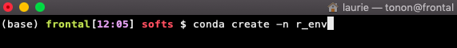

Moi je le laisse dans le dossier par défaut mais c’est comme vous voulez:

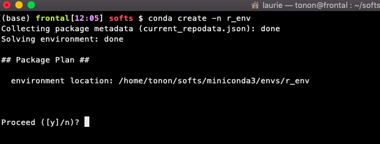

Tout s’est bien passé:

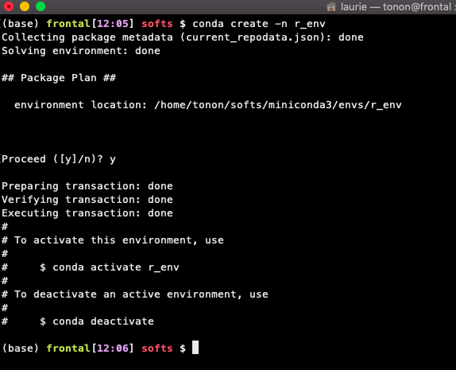

Et maintenant j’installe R:

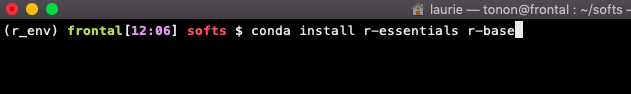

Je suis d’accord pour installer tous ces packages:

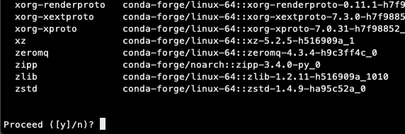

Une fois fini c’est prêt:

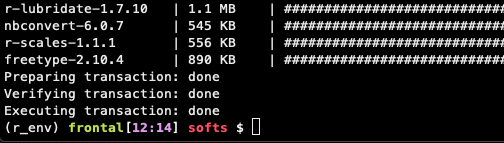

On peut vérifier que, dans mon environnement r_env la version de R est celle que je viens d’installer:

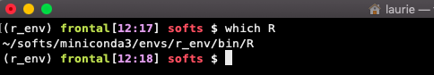

Allez on se lance:

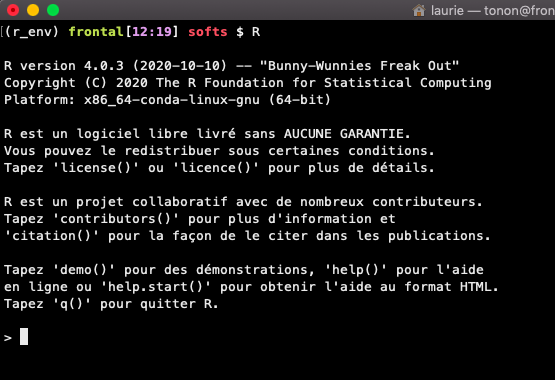

C’est tout bon je peux commencer à utiliser R.

Voilà maintenant vous savez utiliser conda pour installer vos softs.

Par contre pour le moment on a fait tout ça sur la machine frontal de gnomic. Mais pour utiliser nos softs installés on se rappelle la règle: **ON NE LANCE PAS DE JOB SUR LA FRONTALE**.  
Pour cela on utilise le cluster de calcul via slurm, et on va voir comment dans la deuxième partie.

# Slurm

## Qu’est-ce que c’est?

Slurm est ce que l’on appelle un job scheduler. C’est l’équivalent de PBS/Torque que l’on utilisait jusqu’à présent.  
C’est un ensemble de commande qui vont nous permettre de lancer et monitorer des jobs sur les noeuds de calcul.

## Utiliser slurm pour mes jobs

### Les partitions

Les 12 noeuds de calculs sont séparés en trois partitions:

- research: utilise uniquement les noeuds 5 à 12
- diagnostic: utilise uniquement les noeuds 1 à 4
- production: utilise tous les noeuds

Chaque utilisateur est autorisé à lancer ses jobs sur une ou plusieurs partition selon son profil.  
La plupart d’entre nous utilisera la partition research qui est configurée par défaut pour les utilisateurs de la plateforme.  
Si pour une raison particulière il vous faut lancer un job sur une autre partition il faut ajouter l’option “-p” aux commandes de slurm, par exemple *-p production*.

Pour voir les partitions disponibles:

```bash
sinfo
```

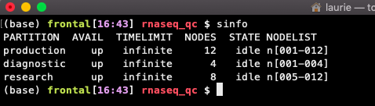

### Surveiller les jobs

Pour lister les jobs en train de tourner:

```bash
squeue
```

Les jobs sont Running (R) ou pending (PD).

Il y a de nombreuses options pour filtrer les résultats:

Uniquement mes jobs:

```bash
squeue -u tonon
```

Uniquement les jobs de la partition research:

```bash
squeue -p research
```

### Lancer un job intéractif

Voilà comment se connecter sur un noeud en intéractif pour travailler:

```bash
srun --mem=4G -c 1 --pty bash
```

Avec cette commande on lance un job interactif sur la partition research en réservant 4 Giga de mémoire et 1 cpu.

### Lancer un job

Pour lancer un script sur le cluster il faut préparer un fichier de lancement.  
Exemple avec le fichier *myjob.sh*, qui lance un job avec 8 cpu, 40 giga de mémoire pour 24h max:

```bash
#!/usr/bin/env bash

#SBATCH --mem=40g
#SBATCH --time=24:00:00
#SBATCH --ntasks=8
#SBATCH --output=R-%x.out.%j
#SBATCH --error=R-%x.err.%j

command_to_launch
```

Et pour lancer sur le cluster:

```bash
sbatch -J jobname myjob.sh
```

Les lignes commencant par “#SBATCH” ne sont pas des commentaires et sont bien interprétées au lancement du script.  
Il est également possible de ne pas utiliser ces lignes et de mettre toutes les options sur la ligne de commande, ou inversement.

### Annuler un job

Pour arrêter un job en train de tourner:

```bash
scancel jobid
```

On peut récupérer le jobid avec la commande squeue.

## Un exemple

Pour illustrer toute les étapes de ce document on va suivre un exemple complet. L’idée ici est de créer un script qui index le génome humain avec salmon et de le lancer sur le cluster.  
Pour cela on va suivre les étapes suivantes:

1. Installer salmon avec conda
2. Créer mon script pour ma commande salmon
3. Lancer la commande sur le cluster

On commence par installer salmon:

```bash
conda create -n salmon_v1.4
conda activate salmon_v1.4
conda install salmon=1.4.0
conda deactivate
```

On part du principe qu’on a déjà récupéré les fichiers fasta du génome et transcriptome humain de référence: *GRCh38.primary_assembly.genome.fa.gz* et *gencode.v37.transcripts.fa.gz*

On créé donc notre script index_conda.sh

```bash
#!/bin/bash
#
#SBATCH --job-name=salmon_idx
#SBATCH --output=salmon_idx.out
#SBATCH --mem=40G
#
#SBATCH --ntasks=10
#SBATCH --time=10:00:00

source activate salmon_v1.4
grep "^>" <(gunzip -c /home/tonon/references/GRCh38.primary_assembly.genome.fa.gz) | cut -d " " -f 1 > /home/tonon/references/decoys.txt
sed -i.bak -e 's/>//g' /home/tonon/references/decoys.txt
cat /home/tonon/references/gencode.v37.transcripts.fa.gz /home/tonon/references/GRCh38.primary_assembly.genome.fa.gz > /home/tonon/references/gentrome.fa.gz
salmon index -t /home/tonon/references/gentrome.fa.gz -d /home/tonon/rnaseq_qc/decoys.txt -p 10 -i /home/tonon/rnaseq_qc/salmon_1.4_grch38_idx --gencode
```

Et on lance le script:

```bash
sbatch index_conda.sh
```

Et voilàààà.